# Lecture 23: Private Cryptocurrencies

### Announcements

- Please pick up your card
- Course evaluations are now open
- Remaining graded work (must be submitted on Gradescope by 6pm on the due date)
  - Friday 12/5: Reading 12
  - Wednesday 12/10: Test 3 retries, and Homework 10 (will be posted later today)
- Final exam is on Friday 12/19 at 9-11am

### Learning outcomes

By the end of today’s lecture, you will learn:

- The difference between pseudonymous and anonymous financial payments
- How Zcash uses zero knowledge proofs to build “shielded transactions” that hide the sender, receiver, and amount of a transaction
- How Mina uses recursive zero knowledge proofs to design a succinct blockchain

### Review

The goal of this course is to teach you how to think from an adversarial perspective, and to learn how cryptography can be used to build **secure and trustworthy** data science systems that:

- Reduce the level of trust required in other entities
- Understand exactly what you are trusting other entities to do (i.e., how things could go wrong, and what needs to happen for a bad outcome to occur)
- Verify that trusted entities are acting correctly
- Have free will to change which entities you trust, and for what purposes

This course covers four fundamental topics.

1. *Protecting data integrity*: authenticating data and its sender over the Internet, without needing to rely on intermediaries (like Internet service providers)
2. *Protecting data availability*: building consensus in data and financial transactions, without needing to rely on intermediaries (like banks or social media websites)
3. *Protecting data confidentiality*: sharing data only with specific people on the Internet, without needing to give your data to intermediaries (like big tech companies)
4. *Protecting data science*: performing and verifying data analysis, without sharing your data with any intermediaries (like cloud providers or auditors)

The cryptographic tools studied in this course allow for data-driven decision making, without the need to place blind trust in another company or person.

So far we have studied each of these scientific tools in isolation. For the last few classes of this semester, I want to look at:

- what happens *when we combine them together* to build really powerful data science tools, and
- the impact that cryptography can have on society (in both good and bad ways)

### Course evaluation

[output not shown]

## 23.1 The challenge of pseudonymity

**Do not invest in cryptocurrencies!** It is a great way to **lose** money.

Recall that Bitcoin transactions are “pseudonymous.”

- Alice and Bob never have to write their names on the blockchain
- But their transaction history is public to the world, and that might be used to identify them

Even if *the blockchain itself* doesn’t reveal the sender and receiver’s identity, it’s entirely possible that people can find out about your transaction in other ways. For instance:

- Perhaps Alice reuses the same public key with many people. Now Mallory can track Alice’s other transactions.
- Perhaps Mallory watches over Alice’ shoulder as she posts a cryptocurrency transaction to buy coffee.
- Perhaps the sender just announces the transaction on the Internet.

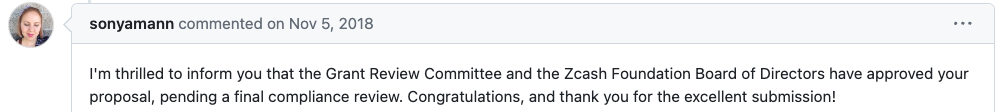

  Source: [Zcash Foundation](https://github.com/ZcashFoundation/GrantProposals-2018Q2/issues/36)

- Perhaps the amount of the transaction is so large that only a few people or organizations in the world could even produce it.

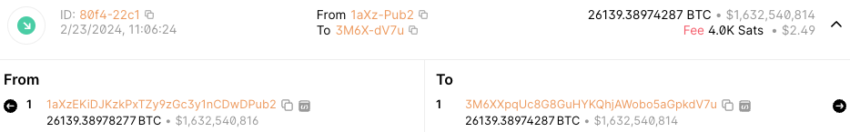

  Source: [Bitcoin transaction 80f4c71605a220a7e7c22ba46eaf6687f1748034918409297235f197176922c1](https://mempool.space/tx/80f4c71605a220a7e7c22ba46eaf6687f1748034918409297235f197176922c1)

- Perhaps Mallory is smart enough to connect many transactions on the blockchain together.

**Interactive question.** Consider this transaction posted not long after the previous one. Which of the two destination addresses do you think is the *change address* that is returning money back to the original sender?

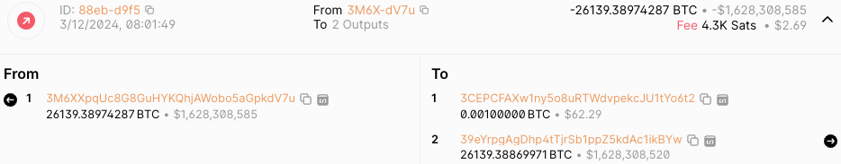

Source: [Bitcoin transaction 88ebf4c7dcfe35114bc0908691a5c990623bd77dc5eed8927636f2fbb321d9f5](https://mempool.space/tx/88ebf4c7dcfe35114bc0908691a5c990623bd77dc5eed8927636f2fbb321d9f5)

1. Output #1 returns money to the original sender
2. Output #2 returns money to the original sender

A clever Mallory might be able to perform these kinds of linking attacks in order to connect *many* transactions on the blockchain.

This [*Wired* magazine article](https://www.wired.com/story/27-year-old-codebreaker-busted-myth-bitcoins-anonymity/) describes research by Prof. Sarah Meiklejohn (now at University College London) to connect many Bitcoin transactions in 2013.

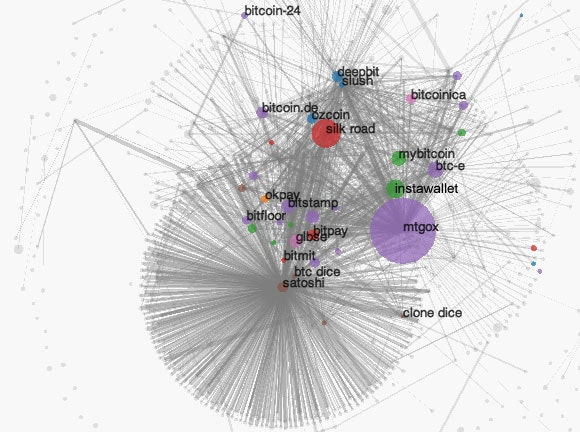

Source: [Wired](https://www.wired.com/story/27-year-old-codebreaker-busted-myth-bitcoins-anonymity/)

## 23.2 The Zcash cryptocurrency

Bitcoin achieved its goal of a secure, decentralized ledger through **replication** – that is, making every financial transaction public to the world.

- In other words, Bitcoin achieves strong integrity and availability
- But it does so at the expense of confidentiality

The problems of *establishing consensus* and *preventing double spending* are indeed hard, and we spent several lectures discussing them. But why do they require the whole world to know exactly when and where you buy coffee in the morning? One problem doesn’t seem related to the other.

Today, let’s explore how to use zero knowledge proofs in order to design new cryptocurrencies that provide **anonymous payments**.

We will start by talking about [Zcash](https://zips.z.cash/protocol/protocol.pdf), which is based on the [Zerocoin](https://sites.cs.ucsb.edu/~rich/class/cs293b-cloud/papers/zerocoin.pdf) and [Zerocash](https://eprint.iacr.org/2014/349.pdf) papers.

### Two kinds of addresses

Recall that in Bitcoin, you must maintain a *secret key*, from which you can derive a *public key*. As the name suggests, a public key **can** be posted to the world – it is safe to do so, in the sense that nobody will be able to calculate your secret key from it, so your coins are safe.

But just because you **can** publish a public key, doesn’t mean that you **have** to do so.

- In Bitcoin, the hash of each public key is immediately posted to the ledger, and the real public key is posted whenever you want to spend a transaction. That’s why we see them on mempool.space.
- But publishing your public key can lead to de-anonymization attacks, where others can figure out which real-world people correspond to which alphanumeric sequence of keys.

By contrast, the Zcash currency has two kinds of addresses:

- **Transparent addresses**, which work exactly like Bitcoin does
- **Shielded addresses**, which are new and different

If you and your friends only ever used **transparent addresses** in Zcash, everything would look basically the same as it does in Bitcoin.

- You can send money to your friends by digitally signing a transaction to pay their addresses
- You can download the entire blockchain of all transactions that everyone has ever sent using transparent addresses

There’s only one thing that might look a bit different to you: there is one account that stores an incredibly large amount of money in it.

- Upon closer inspection, actually there are a large number of transactions that take money into and out of that wallet
- Even stranger, there are some weird transactions posted to the blockchain that you cannot decipher

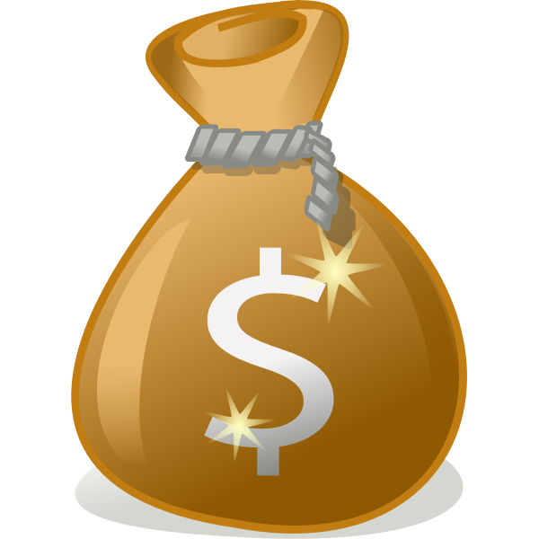

Giant address

That’s because the big pool of money is actually the sum total of all **shielded accounts**. Anyone with a shielded account can move some (but not all!) of the money in the pool.

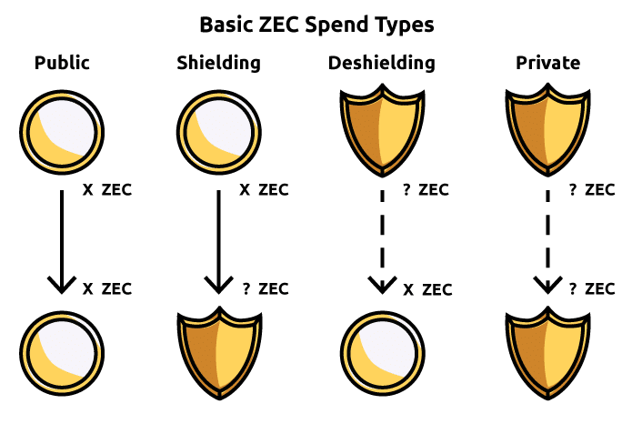

### Inspecting Zcash transactions

Let’s look at a transaction between two shielded accounts.

- It has a transaction id, as normal, but the identity of the sender + recipient accounts is concealed
- From the perspective of the public blockchain, no money has moved! It stayed in the money bag… except for 0.0001 Zcash, which goes from the money bag to the miner as the transaction fee

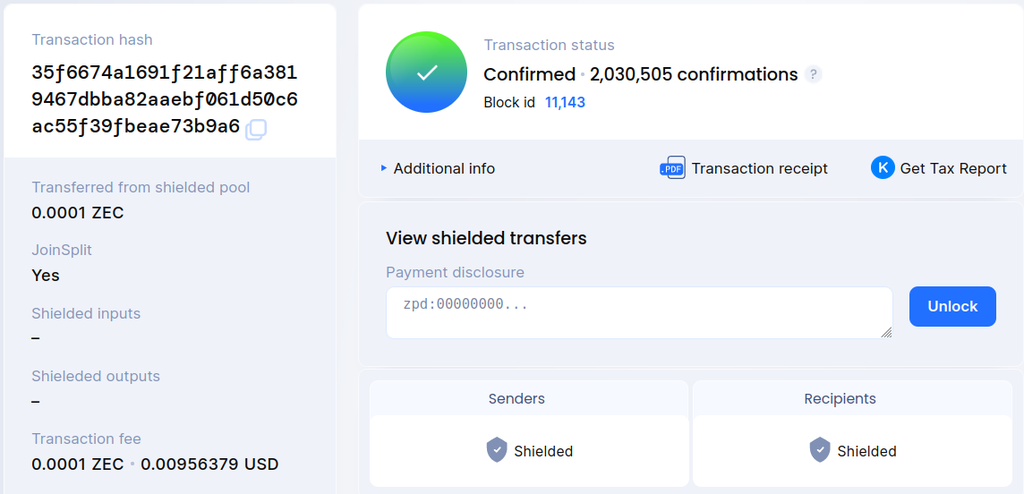

Private transaction between two shielded accounts (source: [Blockchair](https://blockchair.com/zcash/transaction/35f6674a1691f21aff6a3819467dbba82aaebf061d50c6ac55f39fbeae73b9a6))

Here is a transaction that sends money from the giant shielded money bag to a “normal” public account.

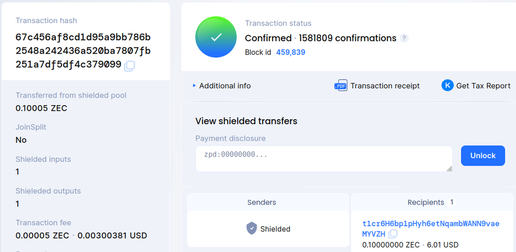

Deshielding transaction from a shielded account to a transparent one (source: [Blockchair](https://blockchair.com/zcash/transaction/67c456af8cd1d95a9bb786b2548a242436a520ba7807fb251a7df5df4c379099))

Public addresses on Zcash always begin with the letter `t`, and shielded accounts begin with the letter `z` (although we cannot see the shielded address here via the public view of the blockchain; only the account owner would see that).

## 23.3 How Zcash private transactions work

[This portion of the lecture notes is derived from the blog post [Electric Coin Company: How Transactions Between Shielded Addresses Work](https://electriccoin.co/blog/zcash-private-transactions/).]

In order to explain the transactions between shielded addresses, it is helpful to recall how transactions between transparent, Bitcoin-like addresses work. (To simplify the explanation, I will ignore the scripting language and suppose that a transaction only contains a digital signature.)

### UTXO table

Recall that Bitcoin is based on the **unspent transaction** (UTXO) model. For a transaction to be valid:

- The sender must specify a prior transaction in which they received their coins
- The sender cannot send out more coins than they previously received (and the difference goes to the miner as fees)

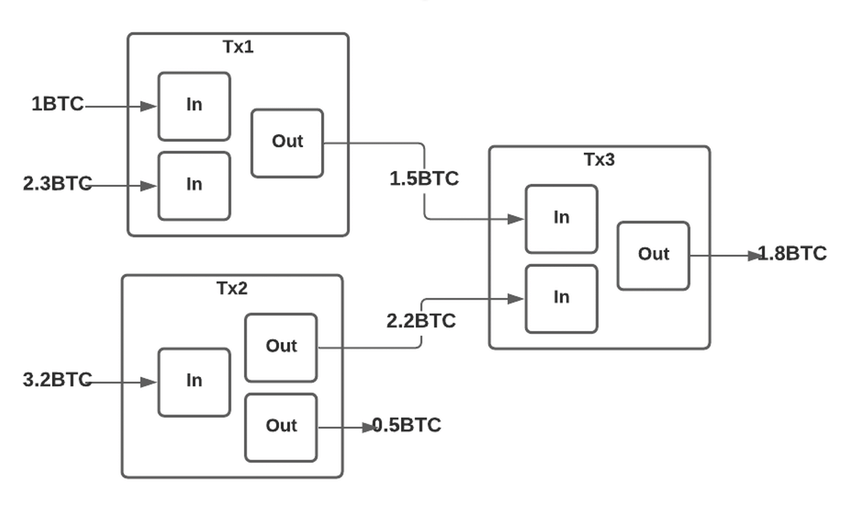

Bitcoin transactions (image source: [researchgate.net](https://www.researchgate.net/publication/350479019/figure/fig3/AS:1023126523621376@1620943780846/Concept-of-Unspent-Transaction-Outputs-UTXOs.ppm))

In other words, we can think of the blockchain as storing a table of hashed public keys and associated monetary amounts.

After the first two transactions in the above figure, the table would look something like this.

| Hashed key | Amount |
| --- | --- |
| H(pk1) | 1.5 |
| H(pk2) | 2.2 |
| H(pk3) | 0.5 |

Here is the first change that Zcash makes, which on its own is relatively minor.

- Let’s say that each transaction output has an associated “*serial number*” $r$: you can think of this like the serial number on a dollar bill
- The sender of each transaction creates the serial number and sends it privately to the recipient

| Hashed key | Amount |
| --- | --- |
| H(pk1, r1) | 1.5 |
| H(pk2, r2) | 2.2 |
| H(pk3, r3) | 0.5 |

When the third transaction is posted to the blockchain, suppose that the sender posts both a digital signature and the serial numbers of the just-spent coins.

Afterward, all nodes:

- Check the validity of the digital signature
- *Check that the serial numbers have never been spent before*
- Make sure that the outgoing amount is no more than the incoming amount

If all checks pass, the nodes update their record of the unspent transactions as follows.

[output not shown]

The nodes also keep a list of spent serial numbers: in this case `r1` and `r2`. Because serial numbers are unique, this is a quick way to check that nobody posts the same transaction twice.

### Adding ZK

The main idea of Zcash is to:

> do the work described above **in zero knowledge**.

Concretely, the parties maintain a hashed version of the above table, so that nobody can read the keys *or* the amounts.

To make the above transaction, the sender posts hashes of the serial numbers `H(r1)` and `H(r2)`—which are called **nullifiers** in Zcash-lingo—along with a zero knowledge proof that:

1. The sender knows values `pk1` and `pk2` such that when you hash them together with the serial numbers, the results are the hashed keys `H(pk1, r1)` and `H(pk2, r2)` that are being spent.
2. The sender knows the secret keys corresponding to the public keys `pk1` and `pk2`. (This is essentially what the digital signature did before… in fact, a signature is a special case of a ZK proof.)
3. These nullifiers have never been used in a previous transaction. This is where the name comes from – posting `H(r1)` effectively *nullifies* the coins held by `pk1` to ensure that they aren’t spent twice.
4. The amount of money being sent to the recipient is less than or equal to the amount in the current account. (That is: the sender is only giving away the part of the giant money bag that it has the right to use.)

The sender creates a non-interactive zk-SNARK and posts it to the blockchain, and everyone verifies it. If so, they add `H(r1)` and `H(r2)` to their nullifier set.

The takeaway here is that:

- All of the money owned by all shielded accounts is lumped together into one giant account.
- With the correct key material and serial numbers, you have the right to re-assign some of it to belong to someone else. You post a ZK proof to convince the rest of the world that you have this right.
- But: the rest of the world never learns the sender’s keys, receiver’s keys, or the amount transferred!

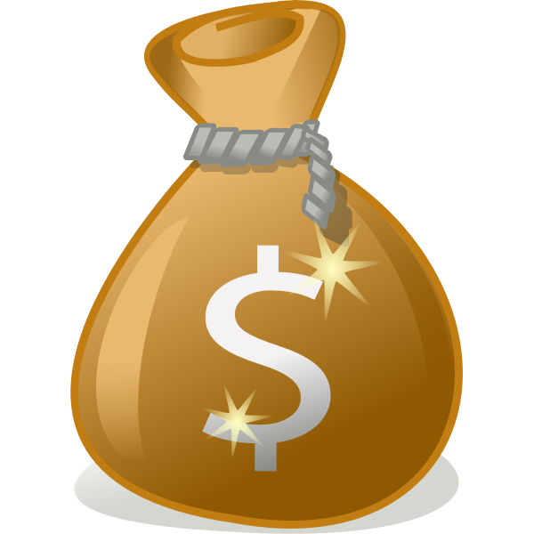

The actual Zcash protocol includes many clever tricks to make this process more efficient. For instance: rather than storing a big table of all hashed keys and hashed amounts, instead all of that data is put into a *Merkle tree*.

Transactions that move money between shielded and transparent accounts work similarly. In this case, it is publicly visible that the size of the giant account is increasing or decreasing, but nobody knows who has control of the money that just entered or left.

But there is one unfortunate catch:

- To spend money from a shielded address, the sender needs to create a ZK proof. Part of the statement being proved is that “nobody has ever used this nullifier in any other transaction in the blockchain.”
- So, in order to construct this proof, the sender first needs to download the entire blockchain. (The Zcash blockchain size is currently [over 250 GB](https://mainnet.zcashexplorer.app/).)

Hence, unlike in Bitcoin, it’s not possible for light clients to spend money just by posting a signature and letting the nodes and miners sort out the details. In some sense, everyone needs to be a full node.

## 23.4 Interactivity vs transferrability of ZK proofs

In the last lecture, we discussed the *Fiat-Shamir transform*, which was a way to convert an interactive proof into a non-interactive one.

Recall that this transformation replaced verifier Victor’s random challenge with a challenge that was calculated by the prover using a cryptographic hash function.

[figure not shown]

MPC-in-the-head (source: [Trail of Bits blog](https://blog.trailofbits.com/2020/12/14/reverie-an-optimized-zero-knowledge-proof-system/))

There is actually a subtle yet important difference between the interactive and non-interactive ZK proofs.

- An interactive zero knowledge proof is **non-transferrable**. Remember when you watched Julie prove in lab that she knew the solution to the Sudoku puzzle. After watching that, you did not learn the solution, and *also you did not gain the ability to prove knowledge of the solution to anyone else*.
- By contrast, a non-interactive proof is inherently **transferrable**. If Julie had instead posted a non-interactive ZK proof (say, using [her MPC-in-the-head protocol](https://eprint.iacr.org/2021/478.pdf)), then you would not be convinced that *she* knows the solution to the Sudoku puzzle. It could also have been the case that Julie received the non-interactive proof from somebody else.

Just remember: you always get exactly one of **interactive** or **transferrable**.

- In a cryptocurrency on top of a peer-to-peer gossip network, transferrability is a useful feature to relay the proof across the world!
- But there are times when transferring a proof would be actively bad, such as if you wanted to prove knowledge of a password in order to log into an account.

## 22.5 Recursive Proofs

*If* an application allows for a non-interactive (and thus transferrable) proof, then you can do something magical with it. Remember that ZK proofs enable the prover to demonstrate to the world that they possess some information, without the need to broadcast it to the world.

- Typically the prover wants to hide the underlying information for confidentiality reasons
- But the idea works just as well if the prover simply wants to *avoid sending the data* for efficiency reasons

Here’s an intriguing question: if a ZK proof is transferrable, then can we use it as a witness to prove other statements?

**Interactive question.** Suppose that you have 20 Sudoku puzzles. You ask all of your classmates to solve one Sudoku puzzle and to give you a non-interactive ZK proof that they know the solution.

Then, you want to post on the internet a non-interactive proof that all 20 Sudoku puzzles are solvable. How can you do this?

1. Concatenate all 20 ZK proofs together
2. Build a new ZK proof of the statement “I know the solution to all 20 Sudoku puzzles”
3. Build a new ZK proof of the statement “I have in my possession valid non-interactive ZK proofs of all 20 Sudoku puzzles”

*Answer*. Either option A or C will work… and I want to argue that option C is the best choice here.

- Concatenating all 20 proofs will work, but it is not **succinct**. It is $20 \times$ the size of a single proof.
- I cannot prove “I know the solution to all Sudoku puzzles,” because I don’t know the solutions.
- But what I can do is prove “I have in my possession valid non-interactive ZK proofs of all 20 Sudoku puzzles.” This is a perfectly valid thing to do! It is called a **recursive zero knowledge proof**, or **proof-carrying data**.

This is somewhat mind-blowing. You can attach a tiny proof to any piece of data that explains its full provenance – which raw data it came from, and what data analysis was performed in order to produce it.

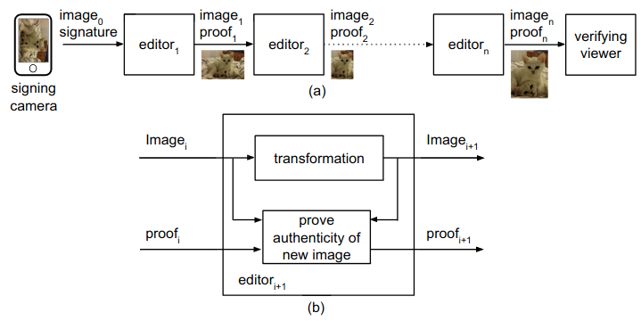

Recursive proofs of photograph alterations (source: [PhotoProof](https://ieeexplore.ieee.org/document/7546506), by Assa Naveh and Eran Tromer)

This technique has a wide range of applications in data science. But today we will look at one application involving cryptocurrencies.

### Mina cryptocurrency

Every cryptocurrency we have seen so far – Bitcoin, Ethereum, and Zcash – fundamentally relies on a blockchain data structure.

- The individual transactions might include digital signatures, smart contracts, or ZK proofs; no matter what, they are periodically grouped together into a block and appended to the existing chain.
- As a result, the blockchain for each cryptocurrency grows linearly with the number of transactions that have ever been made. For instance, the Bitcoin blockchain is currently [703 GB in size](https://www.blockchain.com/explorer/charts/blocks-size).

Using recursive zero knowledge proofs, we can *substantially* reduce the size of the blockchain.

Let’s imagine that the following picture contains part of the Zcash blockchain. Each block contains a series of transactions, and suppose that each one is a zero knowledge proof corresponding to a private transaction.

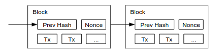

**Question.** How can the miner reduce the size of a block?

*Answer*. The miner can produce a *recursive proof* of the following statement:

> “I have seen a series of proofs by individual senders, they are all valid, and they result in specific nullifiers being added to the set.”

Remember that a single zk-SNARK has constant size, independent of the complexity of the statement that produced it. So we can compress all signatures in a block effectively down to the size of a single transaction!

But why stop there? Recursion is such a powerful technique that we can use it between blocks too.

- Recall that when a new client joins the cryptocurrency, the first thing it must do is to download the blockchain (or at least the headers) and verify all of them. That’s a lot of work, and we’re asking *every* new client to do the same thing.
- So here is an idea: when a miner produces a block, it proves that *all blocks since the start of time are valid*.

That sounds like a lot of work, but actually it isn’t, thanks to the power of recursion. The miner of block $N-1$ has already posted a proof that the first $N-1$ blocks are valid. So the current miner can create a proof that:

> “I have seen individual proofs that each transaction in block $N$ are valid, **and** I have seen a proof that the first $N-1$ blocks contain valid transactions as well.”

The amazing result of all this recursion is a **succinct blockchain**.

The [Mina](https://minaprotocol.com/wp-content/uploads/technicalWhitepaper.pdf) blockchain can be summarized in about 20kB of data, even though the number of transactions on the network is continually growing.

- The zk-SNARK is about 1 kB in size
- The Merkle tree of the account table (which I mentioned earlier today) is about 20 kB in size

This is so small that anyone can easily download it and verify the entire blockchain.

Note that *some* people need to act as:

- Full nodes that store the entire blockchain and perform the consensus protocol on top of it.
- Miners that produce new blocks to add to the chain.

Fortunately, most people can act as **ultralight clients**. Thanks to the (recursive) ZK proofs, they only need the succinct summary of the blockchain in order to verify their balance, unlike with Bitcoin where the clients needed to place trust in the nodes/miners.

### Summary

- Today we have seen the privacy benefits that accrue when we combine zero knowledge proofs (Unit 4) with cryptocurrencies (Unit 2 of this course).
- It turns out that combining consensus protocols with cryptocurrencies also produces a huge win: we can replace the energy-intensive proof of work puzzles with an environmentally-friendly leader election protocol. This is the core idea behind a cryptocurrency called [Algorand](https://algorand.co/).
- More generally: each of the cryptographic tools we have built in this course is powerful on their own. And they can become even more powerful when we find clever ways to use them together!